# Tugas : analisis suara alami dengan FFT (23 Sep 2022)

- Rekam suara dalam waktu 3 sekon, kemudian simpan dalam *.wav
  - misal: rekam suara petik senar gitar no 1, 3, 6 (ada 3 file: suara_senar_1.wav, ...)
- Menghitung koefisien Fourier dengan FFT:
  - Gunakan Jupyter Notebook untuk membaca .wav
  - Hitunglah koefisien Fourier dari masing-masing suara, kemudian simpan koef dalam file .csv (misal: FFT_suara_senar_1.csv)
  - Plot koef Fourier tsb untuk masing-masing file dan bandingkan. Adakah perbedaannya? Jelaskan
- Lakukan ekstraksi ciri audio, meliputi:
  - Time-Domain Audio Features, meliputi besaran:
    - Energy, Zero-Crossing Rate, Entropy of Energy
    - Gunakan window time-frame, misalnya 0.1 s
    - Simpan data fitur ke file scsv, misal: fitur_EZE_suara_senar_1.csv
  - Frequency-Domain Audio Features
    - Spectral Centroid and Spread: fitur_SC_suara_senar_1.csv
    - Spectral Entropy: fitur_SE_suara_senar_1.csv
    - Spectral Flux: fitur_SF_suara_senar_1.csv
    - MFCC: fitur_MFCC_suara_senar_1.csv
- Note: Gunakan paket/modul Python yang sesuai
- Nama : Muhammad Rizky Anugrah
- NIM : 1306620089
- Kelas: Fisika B
- Dosen: Nama: Dr.rer.nat. Bambang Heru Iswanto

## IMPORT

```python
import sounddevice as sd
from scipy.io.wavfile import write
import wavio as wv
import matplotlib.pyplot as plt
import numpy as np
import librosa
import IPython.display as ipd
from scipy.fft import fft, fftfreq
import pandas as pd
import antropy as an
import wave
import os
from playsound import playsound
from scipy.stats import entropy as en
```

## SUARA SENAR

```python
base_dir = "D:\KAPSEL\Muhammad Rizky Anugrah_1306620089_Tugas 3 Analisis Suara Alami Dengan FFT"
sinyal1 = "suara_senar_1.wav"
sinyal3 = "suara_senar_3.wav"
sinyal6 = "suara_senar_6.wav"
```

## SUARA SENAR 1

```python
playsound(sinyal1)
```

## SUARA SENAR 3

```python
playsound(sinyal3)
```

## SUARA SENAR 6

```python
playsound(sinyal6)
```

## BUTTON PLAY SUARA SENAR 1

```python
ipd.Audio(os.path.join(base_dir,sinyal1))
```

[interactive chart not shown]

## BUTTON PLAY SUARA SENAR 3

```python
ipd.Audio(os.path.join(base_dir,sinyal3))
```

[interactive chart not shown]

## BUTTON PLAY SUARA SENAR 6

```python
ipd.Audio(os.path.join(base_dir,sinyal6))
```

[interactive chart not shown]

## KOEFISIEN SENAR 1

```python
#Mencari berapa banyak koefisien dari audio tersebut
audio_senar_1,sr_senar_1 = librosa.load(os.path.join(base_dir,sinyal1))
print("Banyaknya koefisien sinyal awal : ",audio_senar_1.shape)

#Mencari koefisien transformasi fourier dari audio tersebut
audio_senar_1_fft = fft(audio_senar_1)
print("Banyaknya koefisien sinyal setelah transformasi :",audio_senar_1_fft.shape)

print("Banyaknya sampling rate dari audio :",sr_senar_1)
```

```
Banyaknya koefisien sinyal awal :  (72442,)
Banyaknya koefisien sinyal setelah transformasi : (72442,)
Banyaknya sampling rate dari audio : 22050
```

```python
#Mencari lamanya durasi audio
duration_1 = librosa.get_duration(audio_senar_1,sr_senar_1)
duration_1
```

```
3.2853514739229026
```

```python
#Karena koefisien fourier sinyal yang di transformasi masih dalam bentuk bilangan kompleks, maka harus dibuat nilai absolutnya agar dalam bentuk bilangan
koefisien_senar_1 = np.abs(audio_senar_1_fft)
print("Koefisien fourier dari sinyal audio",koefisien_senar_1)
```

```
Koefisien fourier dari sinyal audio [34.742817 35.96036  32.72109  ... 33.271416 32.72109  35.96036 ]
```

```python
data_senar_1 = pd.DataFrame((koefisien_senar_1))
data_senar_1.to_csv("FFT_suara_senar_1.csv")
data_senar_1=pd.read_csv('FFT_suara_senar_1.csv')
data_senar_1
```

|  | Unnamed: 0 | 0 |
| --- | --- | --- |
| 0 | 0 | 34.742817 |
| 1 | 1 | 35.960360 |
| 2 | 2 | 32.721090 |
| 3 | 3 | 33.271416 |
| 4 | 4 | 30.166107 |
| ... | ... | ... |
| 72437 | 72437 | 37.451363 |
| 72438 | 72438 | 30.166107 |
| 72439 | 72439 | 33.271416 |
| 72440 | 72440 | 32.721090 |
| 72441 | 72441 | 35.960360 |

72442 rows × 2 columns

```
(100.0, 1000.0)
```

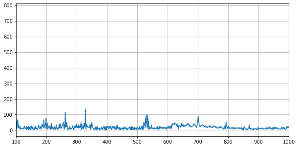

```python
plt.figure(figsize=(10,5))
plt.plot(koefisien_senar_1)
plt.grid(True)
plt.xlim(100,1000)
```

## KOEFISIEN SENAR 3

```python
#Mencari berapa banyak koefisien dari audio tersebut
audio_senar_3,sr_senar_3 = librosa.load(os.path.join(base_dir,sinyal3))
print("Banyaknya koefisien sinyal awal : ",audio_senar_3.shape)

#Mencari koefisien transformasi fourier dari audio tersebut
audio_senar_3_fft = fft(audio_senar_3)
print("Banyaknya koefisien sinyal setelah transformasi :",audio_senar_3_fft.shape)

print("Banyaknya sampling rate dari audio :",sr_senar_3)
```

```
Banyaknya koefisien sinyal awal :  (74324,)
Banyaknya koefisien sinyal setelah transformasi : (74324,)
Banyaknya sampling rate dari audio : 22050
```

```python
#Mencari lamanya durasi audio
duration_3 = librosa.get_duration(audio_senar_3,sr_senar_3)
duration_3
```

```
3.370702947845805
```

```python
#Karena koefisien fourier sinyal yang di transformasi masih dalam bentuk bilangan kompleks, maka harus dibuat nilai absolutnya agar dalam bentuk bilangan
koefisien_senar_3 = np.abs(audio_senar_3_fft)
print("Koefisien fourier dari sinyal audio",koefisien_senar_3)
```

```
Koefisien fourier dari sinyal audio [253.00389 238.74492 212.21896 ... 173.61841 212.21896 238.74492]
```

```python
data_senar_3 = pd.DataFrame((koefisien_senar_3))
data_senar_3.to_csv("FFT_suara_senar_3.csv")
data_senar_3=pd.read_csv('FFT_suara_senar_3.csv')
data_senar_3
```

|  | Unnamed: 0 | 0 |
| --- | --- | --- |
| 0 | 0 | 253.00389 |
| 1 | 1 | 238.74492 |
| 2 | 2 | 212.21896 |
| 3 | 3 | 173.61841 |
| 4 | 4 | 150.36801 |
| ... | ... | ... |
| 74319 | 74319 | 117.78916 |
| 74320 | 74320 | 150.36801 |
| 74321 | 74321 | 173.61841 |
| 74322 | 74322 | 212.21896 |
| 74323 | 74323 | 238.74492 |

74324 rows × 2 columns

```
(100.0, 1000.0)
```

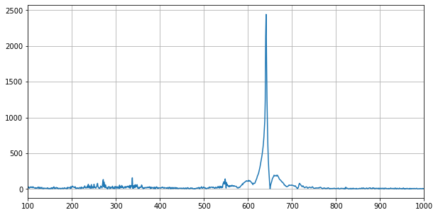

```python
plt.figure(figsize=(10,5))
plt.plot(koefisien_senar_3)
plt.grid(True)
plt.xlim(100,1000)
```

## KOEFISIEN SENAR 6

```python
#Mencari berapa banyak koefisien dari audio tersebut
audio_senar_6,sr_senar_6 = librosa.load(os.path.join(base_dir,sinyal6))
print("Banyaknya koefisien sinyal awal : ",audio_senar_6.shape)

#Mencari koefisien transformasi fourier dari audio tersebut
audio_senar_6_fft = fft(audio_senar_6)
print("Banyaknya koefisien sinyal setelah transformasi :",audio_senar_6_fft.shape)

print("Banyaknya sampling rate dari audio :",sr_senar_6)
```

```
Banyaknya koefisien sinyal awal :  (74324,)
Banyaknya koefisien sinyal setelah transformasi : (74324,)
Banyaknya sampling rate dari audio : 22050
```

```python
#Mencari lamanya durasi audio
duration_6 = librosa.get_duration(audio_senar_6,sr_senar_6)
duration_6
```

```
3.370702947845805
```

```python
#Karena koefisien fourier sinyal yang di transformasi masih dalam bentuk bilangan kompleks, maka harus dibuat nilai absolutnya agar dalam bentuk bilangan
koefisien_senar_6 = np.abs(audio_senar_6_fft)
print("Koefisien fourier dari sinyal audio",koefisien_senar_6)
```

```
Koefisien fourier dari sinyal audio [36.646877 39.443336 47.86897  ... 52.272762 47.86897  39.443336]
```

```python
data_senar_6 = pd.DataFrame((koefisien_senar_6))
data_senar_6.to_csv("FFT_suara_senar_6.csv")
data_senar_6=pd.read_csv('FFT_suara_senar_6.csv')
data_senar_6
```

|  | Unnamed: 0 | 0 |
| --- | --- | --- |
| 0 | 0 | 36.646877 |
| 1 | 1 | 39.443336 |
| 2 | 2 | 47.868970 |
| 3 | 3 | 52.272762 |
| 4 | 4 | 49.799847 |
| ... | ... | ... |
| 74319 | 74319 | 25.645850 |
| 74320 | 74320 | 49.799847 |
| 74321 | 74321 | 52.272762 |
| 74322 | 74322 | 47.868970 |
| 74323 | 74323 | 39.443336 |

74324 rows × 2 columns

```
(100.0, 1000.0)
```

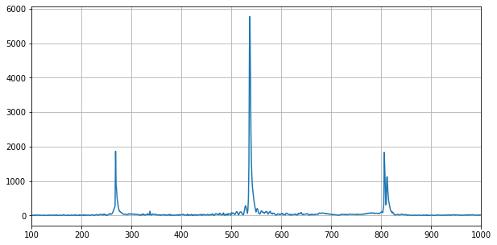

```python
plt.figure(figsize=(10,5))
plt.plot(koefisien_senar_6)
plt.grid(True)
plt.xlim(100,1000)
```

## Membandingkan Perbedaan Yang Telah dihasilkan

Berdasarkan plotting koefisien fourier dari 3 senar yaitu senar 1, 3 dan 6 menghasilkan suatu perbedaan. Pada plotting koefisien senar 1 titik tertinggi berada pada angka 100-200. Pada plotting senar ke 3 menghasilkan titik tertinggi yang berada pada angka 2000-2500. Pada plotting senar ke 6 menghasilkan titik tertinggi yang berada pada angka 5000-6000.

## Energy Senar 1

```python
sigma_E_1 = (1/len(audio_senar_1)*sum(abs(np.square(audio_senar_1))))
Energy_senar_1 = 0
for i in (0,audio_senar_1):
    Energy_senar_1 += (1/len(audio_senar_1)*(abs(np.square(i))))
print("Nilai energy tiap iterasi adalah: ",Energy_senar_1)
print("Jumlah total energy dari semua iterasi adalah: ",sigma_E_1)
```

```
Nilai energy tiap iterasi adalah:  [0.0000000e+00 0.0000000e+00 0.0000000e+00 ... 5.8041943e-10 1.0184892e-09
 0.0000000e+00]
Jumlah total energy dari semua iterasi adalah:  0.0019570628431999993
```

## Energy Senar 3

```python
sigma_E_3 = (1/len(audio_senar_3)*sum(abs(np.square(audio_senar_3))))
Energy_senar_3 = 0
for i in (0,audio_senar_3):
    Energy_senar_3 += (1/len(audio_senar_3)*(abs(np.square(i))))
print("Nilai energy tiap iterasi adalah: ",Energy_senar_3)
print("Jumlah total energy dari semua iterasi adalah: ",sigma_E_3)
```

```
Nilai energy tiap iterasi adalah:  [0.0000000e+00 0.0000000e+00 0.0000000e+00 ... 1.2242318e-10 1.8338091e-11
 0.0000000e+00]
Jumlah total energy dari semua iterasi adalah:  0.014909430596295192
```

## Energy Senar 6

```python
sigma_E_6 = (1/len(audio_senar_6)*sum(abs(np.square(audio_senar_6))))
Energy_senar_6 = 0
for i in (0,audio_senar_6):
    Energy_senar_6 += (1/len(audio_senar_6)*(abs(np.square(i))))
print("Nilai energy tiap iterasi adalah: ",Energy_senar_6)
print("Jumlah total energy dari semua iterasi adalah: ",sigma_E_6)
```

```
Nilai energy tiap iterasi adalah:  [0.0000000e+00 0.0000000e+00 0.0000000e+00 ... 3.6880434e-07 4.5806385e-07
 0.0000000e+00]
Jumlah total energy dari semua iterasi adalah:  0.04029630354135744
```

## Zero-Crossing Rate Senar 1

```python
zcr_senar_1 = librosa.feature.zero_crossing_rate(audio_senar_1)
print("Nilai-nilai Zero Crossing rate antara lain: ",zcr_senar_1)
print("\nBanyaknya nilai-nilai yang berubah tanda atau noice dari audio antara lain: ", zcr_senar_1.shape)
```

```
Nilai-nilai Zero Crossing rate antara lain:  [[0.         0.04492188 0.08007812 0.12011719 0.15185547 0.15429688
  0.15966797 0.14941406 0.14453125 0.12060547 0.10498047 0.09912109
  0.09423828 0.09179688 0.09179688 0.09277344 0.09570312 0.09570312
  0.09375    0.09082031 0.08789062 0.08789062 0.08837891 0.08837891
  0.08789062 0.08789062 0.08886719 0.08984375 0.09277344 0.09277344
  0.09179688 0.09082031 0.08984375 0.09277344 0.09179688 0.08886719
  0.08740234 0.08154297 0.08691406 0.09130859 0.09033203 0.09326172
  0.08886719 0.08789062 0.08691406 0.08447266 0.08154297 0.07958984
  0.07470703 0.07128906 0.06542969 0.05712891 0.06689453 0.07080078
  0.07763672 0.08886719 0.08203125 0.08544922 0.08544922 0.07421875
  0.06884766 0.06787109 0.06347656 0.06494141 0.06884766 0.0625
  0.06494141 0.06884766 0.08105469 0.07861328 0.06884766 0.06884766
  0.06591797 0.0625     0.06835938 0.05517578 0.04101562 0.04296875
  0.03955078 0.06005859 0.06201172 0.06103516 0.06982422 0.05712891
  0.0546875  0.05419922 0.05957031 0.09423828 0.11328125 0.12548828
  0.11767578 0.08886719 0.07421875 0.07226562 0.07714844 0.07910156
  0.08251953 0.08935547 0.08496094 0.08251953 0.08007812 0.07373047
  0.07519531 0.06542969 0.05761719 0.04785156 0.0390625  0.04980469
  0.05175781 0.06054688 0.05908203 0.05175781 0.05908203 0.05664062
  0.05664062 0.06640625 0.06494141 0.06591797 0.08691406 0.08300781
  0.09179688 0.09619141 0.08642578 0.09228516 0.08447266 0.07470703
  0.06835938 0.06835938 0.06933594 0.07080078 0.07568359 0.06591797
  0.06689453 0.06347656 0.05126953 0.05908203 0.06103516 0.06005859
  0.06933594 0.07080078 0.05908203 0.04785156]]

Banyaknya nilai-nilai yang berubah tanda atau noice dari audio antara lain:  (1, 142)
```

## Zero-Crossing Rate Senar 3

```python
zcr_senar_3 = librosa.feature.zero_crossing_rate(audio_senar_3)
print("Nilai-nilai Zero Crossing rate antara lain: ",zcr_senar_3)
print("\nBanyaknya nilai-nilai yang berubah tanda atau noice dari audio antara lain: ", zcr_senar_3.shape)
```

```
Nilai-nilai Zero Crossing rate antara lain:  [[0.         0.05029297 0.09228516 0.12451172 0.14306641 0.11914062
  0.09179688 0.09228516 0.09814453 0.11279297 0.10693359 0.078125
  0.06103516 0.02587891 0.02197266 0.02197266 0.01904297 0.01708984
  0.01904297 0.02050781 0.02197266 0.02294922 0.02392578 0.02587891
  0.02880859 0.03173828 0.03320312 0.03466797 0.03417969 0.03466797
  0.03466797 0.03466797 0.03515625 0.03417969 0.03466797 0.03417969
  0.03417969 0.03466797 0.03417969 0.03466797 0.03466797 0.03466797
  0.03466797 0.03466797 0.03466797 0.03417969 0.03466797 0.03417969
  0.03417969 0.03466797 0.03466797 0.03466797 0.03466797 0.03466797
  0.03417969 0.03466797 0.03417969 0.03417969 0.03466797 0.03417969
  0.03466797 0.03466797 0.03466797 0.03466797 0.03417969 0.03466797
  0.03417969 0.03369141 0.03320312 0.03320312 0.03466797 0.03515625
  0.03564453 0.03564453 0.03466797 0.03466797 0.03466797 0.03466797
  0.03417969 0.03466797 0.03466797 0.03515625 0.03564453 0.03564453
  0.03515625 0.03466797 0.03466797 0.03515625 0.03564453 0.03564453
  0.03515625 0.03466797 0.03759766 0.03759766 0.03857422 0.03857422
  0.03613281 0.03710938 0.03662109 0.03613281 0.03759766 0.03515625
  0.03564453 0.03369141 0.03271484 0.03369141 0.03515625 0.04052734
  0.04296875 0.04541016 0.04736328 0.04736328 0.04345703 0.04150391
  0.04199219 0.04589844 0.04931641 0.04980469 0.04541016 0.04150391
  0.04296875 0.04541016 0.04785156 0.05126953 0.05029297 0.05615234
  0.05517578 0.05566406 0.05126953 0.05615234 0.05419922 0.04931641
  0.05517578 0.0390625  0.03955078 0.04394531 0.04003906 0.04248047
  0.04101562 0.03369141 0.04150391 0.04101562 0.05517578 0.05712891
  0.04101562 0.03271484]]

Banyaknya nilai-nilai yang berubah tanda atau noice dari audio antara lain:  (1, 146)
```

## Zero-Crossing Rate Senar 6

```python
zcr_senar_6 = librosa.feature.zero_crossing_rate(audio_senar_6)
print("Nilai-nilai Zero Crossing rate antara lain: \n",zcr_senar_6)
print("\nBanyaknya nilai-nilai yang berubah tanda atau noice dari audio antara lain: ", zcr_senar_6.shape)
```

```
Nilai-nilai Zero Crossing rate antara lain:
 [[0.         0.11083984 0.16894531 0.20898438 0.24072266 0.171875
  0.16162109 0.17041016 0.17871094 0.18945312 0.19726562 0.19384766
  0.19580078 0.1796875  0.13623047 0.10351562 0.07080078 0.04199219
  0.03710938 0.03173828 0.02832031 0.02832031 0.02929688 0.02832031
  0.02880859 0.02880859 0.02783203 0.02929688 0.02539062 0.02197266
  0.01855469 0.01416016 0.01464844 0.01416016 0.01464844 0.01464844
  0.01416016 0.01464844 0.01416016 0.01464844 0.01416016 0.01513672
  0.01855469 0.02001953 0.02197266 0.02246094 0.02001953 0.01953125
  0.01757812 0.01660156 0.015625   0.01416016 0.01464844 0.01416016
  0.01464844 0.01464844 0.01416016 0.01464844 0.01416016 0.01416016
  0.01464844 0.01416016 0.01464844 0.01464844 0.01416016 0.01464844
  0.01416016 0.01464844 0.01464844 0.01464844 0.01464844 0.01416016
  0.01464844 0.01416016 0.01464844 0.01464844 0.01416016 0.01464844
  0.01416016 0.01416016 0.01464844 0.01416016 0.01660156 0.01757812
  0.01904297 0.01953125 0.01708984 0.01611328 0.01464844 0.01416016
  0.01464844 0.01464844 0.01416016 0.01464844 0.01513672 0.015625
  0.015625   0.01513672 0.01464844 0.01416016 0.01416016 0.01464844
  0.01416016 0.01464844 0.01464844 0.01513672 0.015625   0.01513672
  0.015625   0.01464844 0.01464844 0.01464844 0.01416016 0.01416016
  0.01416016 0.01416016 0.01464844 0.01464844 0.01416016 0.01464844
  0.01416016 0.01464844 0.01464844 0.01416016 0.01464844 0.01416016
  0.01416016 0.01464844 0.01416016 0.01464844 0.01464844 0.01416016
  0.01464844 0.01416016 0.01464844 0.01464844 0.01416016 0.01464844
  0.01416016 0.01416016 0.01464844 0.01416016 0.01464844 0.01464844
  0.01171875 0.00830078]]

Banyaknya nilai-nilai yang berubah tanda atau noice dari audio antara lain:  (1, 146)
```

## Entropy Senar 1

```python
print("Nilai Entropy of Energy dari Energy adalah: ",en(Energy_senar_1))
```

```
Nilai Entropy of Energy dari Energy adalah:  9.16968
```

## Entropy Senar 3

```python
print("Nilai Entropy of Energy dari Energy adalah: ",en(Energy_senar_3))
```

```
Nilai Entropy of Energy dari Energy adalah:  9.382994
```

## Entropy Senar 6

```python
print("Nilai Entropy of Energy dari Energy adalah: ",en(Energy_senar_6))
```

```
Nilai Entropy of Energy dari Energy adalah:  10.28672
```

## Spectral Centroid and Spread

## Spectral Centroid and Spread Senar 1

```python
spectral_centroids_senar_1 = librosa.feature.spectral_centroid(koefisien_senar_1, sr_senar_1)
print("Banyaknya spectral centroid dari koefisien fourier adalah: ",spectral_centroids_senar_1.shape)
print("Sebaran nilai masing-masing dari spectral centroid antara lain: ",spectral_centroids_senar_1)
```

```
Banyaknya spectral centroid dari koefisien fourier adalah:  (1, 142)
Sebaran nilai masing-masing dari spectral centroid antara lain:  [[4308.48084273 3958.32671373 3271.20114817 3230.03519792 2457.31644042
  1661.68875324 1364.68753153 1375.80874458 2974.24289094 2294.45132541
  1603.12083917 1614.81054692 1469.45891414 1389.37885196 1687.73804155
  1592.80122364 1815.90574223 1659.81963785 2187.44069763 2055.24129464
  1434.25549186 1166.74025722 1545.07184638 1310.50861809 1800.85727391
  1984.65533852 2601.01891218 4032.52419353 3600.61788783 2281.51590362
  2588.6104087  2045.80138774 2151.036736   1189.3550128  1300.08977113
  3555.68267378 3785.6704338  2597.86412821 2333.33612596 2366.70816422
  2101.2730453  2652.80635321 2431.5151045  3457.8883502  4262.26288996
  3849.87785496 3169.29296088 3618.77388132 2832.32872837 3075.02037935
  3802.49717253 3880.05881748 3943.29719471 3986.34722176 4121.09726771
  3927.13381104 3880.242275   3403.29736432 3990.05098378 3842.64643366
  4053.60908117 4308.57483191 4286.05877764 4604.2477141  4510.09346487
  4722.5343669  4198.50856669 4221.22208586 4170.11625923 3757.22423359
  2606.82743313 1232.00106102 3559.07670651 3982.51460778 4271.01648103
  4088.26031634 4453.38866145 4664.95791344 4509.62783287 4527.55505263
  4204.63367927 4380.47332322 3833.89043986 4076.56084903 3539.48734212
  3525.08071121 4114.88252308 3921.66310723 4215.87506495 3836.99186484
  4111.67386764 3743.75538281 3688.60474166 2793.01644786 3220.00920707
  3303.33029375 3322.26047431 4254.11286603 4249.7581702  2740.64944754
  2425.43646509 2374.2680045  2101.69004835 2591.18861411 2306.52440735
  3419.41220922 3629.2189964  1961.58146293 1139.58370645 1483.41133762
  2011.06904407 2473.18954475 2313.70924268 2680.27944451 4108.70325662
  3775.43662882 2102.44936854 2111.13501796 1398.34994589 1377.31145229
  1279.74843799 1204.52979646 2092.27877246 2013.38912087 1876.14725889
  1652.4607122  1783.37937465 1572.57348053 1637.81772375 1352.71903943
  1711.91576768 1583.73012313 1718.34906502 3422.80573131 1517.13380375
  1355.23837164 1415.58062679 2383.14662791 2941.1411563  3234.7864334
  3486.50835669 4285.16865983]]
```

```python
spectral_centroids_1 = pd.DataFrame((spectral_centroids_senar_1))
spectral_centroids_1.to_csv("fitur_SC_suara_senar_1.csv")
spectral_centroids_1=pd.read_csv('fitur_SC_suara_senar_1.csv')
spectral_centroids_1
```

|  | Unnamed: 0 | 0 | 1 | 2 | 3 | 4 | 5 | 6 | 7 | 8 | ... | 132 | 133 | 134 | 135 | 136 | 137 | 138 | 139 | 140 | 141 |
| --- | --- | --- | --- | --- | --- | --- | --- | --- | --- | --- | --- | --- | --- | --- | --- | --- | --- | --- | --- | --- | --- |
| 0 | 0 | 4308.480843 | 3958.326714 | 3271.201148 | 3230.035198 | 2457.31644 | 1661.688753 | 1364.687532 | 1375.808745 | 2974.242891 | ... | 1718.349065 | 3422.805731 | 1517.133804 | 1355.238372 | 1415.580627 | 2383.146628 | 2941.141156 | 3234.786433 | 3486.508357 | 4285.16866 |

1 rows × 143 columns

## Spectral Centroid and Spread Senar 3

```python
spectral_centroids_senar_3 = librosa.feature.spectral_centroid(koefisien_senar_3, sr_senar_3)
print("Banyaknya spectral centroid dari koefisien fourier adalah: ",spectral_centroids_senar_3.shape)
print("Sebaran nilai masing-masing dari spectral centroid antara lain: ",spectral_centroids_senar_3)
```

```
Banyaknya spectral centroid dari koefisien fourier adalah:  (1, 146)
Sebaran nilai masing-masing dari spectral centroid antara lain:  [[2431.25367216 1960.90509244 2382.50700144 2601.99739505 2237.64140404
  2247.5261733  2083.70399839 1963.22699385 1881.06998545 2561.2956205
  3415.97028255 2363.79441225 2474.4438885  3041.73062773 2921.29679208
  3737.8970957  3956.34716819 3602.36644752 3693.2529836  3786.16462895
  4249.45039562 2568.57529195 2011.93367307 2988.78914008 3555.06124936
  3570.30522356 4625.31205447 4467.57125396 4254.99178679 4087.15488385
  4789.83887873 4986.20217187 4673.9201236  4473.32525032 4441.99511789
  4381.56845902 4453.10722    4765.85415083 3712.06724004 3452.26957485
  4177.04997264 4485.16881989 4805.00731809 4884.60162877 4950.56402058
  4897.56450284 4929.2538575  4913.38998251 4947.21650764 4919.54262979
  4859.67461192 4673.64585766 4540.61123511 4656.16052582 4750.59048092
  4815.1335723  4943.65961389 4909.9144293  4879.93141019 4865.77984005
  4887.85524594 4917.56708386 4971.15393128 4921.63668776 4814.76311531
  4714.9411712  4165.04307928 4080.3097897  4731.68212854 4742.68674155
  4647.93051924 4544.95329666 3745.51437381 3348.32805979 4493.56993787
  4629.16187178 4740.23750746 4794.64771574 4142.48495002 4102.39400087
  4640.13150993 4813.4973329  4899.77511019 4969.80869854 4935.35562523
  4893.16536176 4861.248702   4891.66805209 4894.44236885 4948.1981118
  4848.66214985 4740.8834145  4696.23747005 4534.2794845  4659.31390868
  4824.22620861 4913.25514533 4946.48614636 4908.49197137 4924.38093071
  4892.65244941 4940.19424715 4900.88060479 4822.89771477 4562.91808787
  4234.47063245 3527.49840967 3579.95182652 4694.62515498 4502.8577862
  4378.57605334 4422.44121494 4485.62736326 4600.62364996 4961.66206149
  4894.66308437 4139.7177242  4197.13269996 4432.83900749 4706.88135334
  3672.70025999 3499.6646685  3361.1657809  2046.69476176 2363.64508508
  4343.37279845 3811.28066383 3702.69608242 3633.11911986 3828.7063301
  4010.48398347 2965.965221   3012.79201619 2595.61835    2315.37806846
  3253.98153311 2773.12813707 1900.90509401 1928.30001989 2071.30401041
  2343.39911363 2133.5520451  2590.55130903 2482.12404091 1955.25045157
  2248.4120814 ]]
```

```python
spectral_centroids_3 = pd.DataFrame((spectral_centroids_senar_3))
spectral_centroids_3.to_csv("fitur_SC_suara_senar_3.csv")
spectral_centroids_3=pd.read_csv('fitur_SC_suara_senar_3.csv')
spectral_centroids_3
```

|  | Unnamed: 0 | 0 | 1 | 2 | 3 | 4 | 5 | 6 | 7 | 8 | ... | 136 | 137 | 138 | 139 | 140 | 141 | 142 | 143 | 144 | 145 |
| --- | --- | --- | --- | --- | --- | --- | --- | --- | --- | --- | --- | --- | --- | --- | --- | --- | --- | --- | --- | --- | --- |
| 0 | 0 | 2431.253672 | 1960.905092 | 2382.507001 | 2601.997395 | 2237.641404 | 2247.526173 | 2083.703998 | 1963.226994 | 1881.069985 | ... | 2773.128137 | 1900.905094 | 1928.30002 | 2071.30401 | 2343.399114 | 2133.552045 | 2590.551309 | 2482.124041 | 1955.250452 | 2248.412081 |

1 rows × 147 columns

```python
spectral_centroids_senar_6 = librosa.feature.spectral_centroid(koefisien_senar_6, sr_senar_6)
print("Banyaknya spectral centroid dari koefisien fourier adalah: ",spectral_centroids_senar_6.shape)
print("Sebaran nilai masing-masing dari spectral centroid antara lain: ",spectral_centroids_senar_6)
```

```
Banyaknya spectral centroid dari koefisien fourier adalah:  (1, 146)
Sebaran nilai masing-masing dari spectral centroid antara lain:  [[2948.60361619 2635.53978982 2679.2438375  2476.22406381 2186.67781023
  2363.80977558 2423.53292753 2116.71932744 2151.88040275 2097.70062798
  2438.63432429 3102.19681264 2253.39070845 2471.88102976 2602.04608264
  3111.76869649 2686.88498645 2140.34161592 2951.10351632 4140.74555145
  3835.56790549 4072.17578906 4442.76733415 4446.59664613 4639.63645269
  4738.92322516 4749.19979018 4675.3701987  4724.38147143 4900.33409681
  4701.50086225 4532.48472158 4489.12656534 4611.26975365 4655.02475598
  4593.4213315  4474.61472122 4605.46793657 4753.9864915  4904.8373194
  4629.95931601 4315.4637826  4340.30687121 4387.88094831 4577.86367047
  4298.13296754 4036.33467279 4029.96064622 4353.2617708  4380.61069058
  3996.83515074 3915.75272555 4078.93083392 4168.71574672 4405.54585482
  4874.91316101 4772.99993178 4423.31812922 4470.67172063 4552.14316986
  4596.81446543 4639.70982767 4377.91180448 4524.06657903 4733.75549023
  4587.84984093 4344.5096809  4309.84725603 4493.56347814 4086.63657648
  2925.05065877 1117.5481393   171.55058883  120.75992127  882.62678616
  2609.09274518 3972.99257868 4472.84120855 4340.17672965 4318.72500245
  4551.71650664 4719.07402371 4576.55891913 4380.62275294 4578.08075896
  4626.79526361 4539.28093329 4515.09169705 4393.67018795 4716.09234129
  4893.12462551 4501.12487452 4179.1678135  4102.17362321 3939.88720207
  3955.20025283 4307.4239281  4420.67842013 4067.40953562 4009.33353512
  4253.6634897  4551.72019453 4425.46379375 4355.58663591 4300.78872063
  4557.32693924 4877.77760557 4798.18129141 4617.45200563 4498.49823339
  4556.70568173 4670.41422408 4622.08915622 4501.84202155 4513.8275202
  4668.16837425 4888.03001142 4768.30198084 4659.97009132 4755.91699462
  4737.83323322 4671.52634148 4465.66830529 4435.66547471 4156.98545838
  3834.05740944 4067.52934152 3298.53870142 2167.79845868 2499.77636443
  3216.80077233 2638.666631   2537.93404171 2228.81523221 2901.34696139
  2565.00608658 2133.358879   2138.3435657  2101.85822325 2408.04859378
  2400.11066508 2135.2014143  2413.72858778 2740.87768894 2619.09870854
  2856.45335863]]
```

```python
spectral_centroids_6 = pd.DataFrame((spectral_centroids_senar_6))
spectral_centroids_6.to_csv("fitur_SC_suara_senar_6.csv")
spectral_centroids_6=pd.read_csv('fitur_SC_suara_senar_6.csv')
spectral_centroids_6
```

|  | Unnamed: 0 | 0 | 1 | 2 | 3 | 4 | 5 | 6 | 7 | 8 | ... | 136 | 137 | 138 | 139 | 140 | 141 | 142 | 143 | 144 | 145 |
| --- | --- | --- | --- | --- | --- | --- | --- | --- | --- | --- | --- | --- | --- | --- | --- | --- | --- | --- | --- | --- | --- |
| 0 | 0 | 2948.603616 | 2635.53979 | 2679.243838 | 2476.224064 | 2186.67781 | 2363.809776 | 2423.532928 | 2116.719327 | 2151.880403 | ... | 2133.358879 | 2138.343566 | 2101.858223 | 2408.048594 | 2400.110665 | 2135.201414 | 2413.728588 | 2740.877689 | 2619.098709 | 2856.453359 |

1 rows × 147 columns

## Spectral Entropy Senar 1

```python
spectral_entropy_1 = 0
for i in (0,audio_senar_1_fft):
    spectral_entropy_1 +=an.spectral_entropy(audio_senar_1_fft, sf = sr_senar_1, normalize = True)
print("Nilai Spectral Entropy didapatkan: ",spectral_entropy_1)
```

```
Nilai Spectral Entropy didapatkan:  1.6388264698393677
```

## Spectral Entropy Senar 3

```python
spectral_entropy_3 = 0
for i in (0,audio_senar_3_fft):
    spectral_entropy_3 +=an.spectral_entropy(audio_senar_3_fft, sf = sr_senar_3, normalize = True)
print("Nilai Spectral Entropy didapatkan: ",spectral_entropy_3)
```

```
Nilai Spectral Entropy didapatkan:  nan
```

## Spectral Entropy Senar 6

```python
spectral_entropy_6 = 0
for i in (0,audio_senar_6_fft):
    spectral_entropy_6 +=an.spectral_entropy(audio_senar_6_fft, sf = sr_senar_6, normalize = True)
print("Nilai Spectral Entropy didapatkan: ",spectral_entropy_6)
```

```
Nilai Spectral Entropy didapatkan:  1.8342630533497088
```

## Spectral Flux Senar 1

```python
spectral_flux_senar_1 = 0
signal_senar_1 = koefisien_senar_1/sum(koefisien_senar_1)
eps_senar_1 = 2.2204e-16
for i in (0,koefisien_senar_1):
    signal_prev_senar_1 = (i-1)/sum((koefisien_senar_1-1)+eps_senar_1)
    spectral_flux_senar_1 += ((signal_senar_1-signal_prev_senar_1)**2)
print("Banyaknya spectral flux dari audio adalah: ",spectral_flux_senar_1.shape)
print("Total besar nilai spektral flux didapatkan: ",spectral_flux_senar_1.sum())
```

```
Banyaknya spectral flux dari audio adalah:  (72442,)
Total besar nilai spektral flux didapatkan:  0.0005433668
```

```python
spectral_flux_1 = pd.DataFrame((spectral_flux_senar_1))
spectral_flux_1.to_csv("fitur_SF_suara_senar_1.csv")
spectral_flux_1=pd.read_csv('fitur_SF_suara_senar_1.csv')
spectral_flux_1
```

|  | Unnamed: 0 | 0 |
| --- | --- | --- |
| 0 | 0 | 6.283137e-08 |
| 1 | 1 | 6.725774e-08 |
| 2 | 2 | 5.581518e-08 |
| 3 | 3 | 5.768376e-08 |
| 4 | 4 | 4.754434e-08 |
| ... | ... | ... |
| 72437 | 72437 | 7.288407e-08 |
| 72438 | 72438 | 4.754434e-08 |
| 72439 | 72439 | 5.768376e-08 |
| 72440 | 72440 | 5.581518e-08 |
| 72441 | 72441 | 6.725774e-08 |

72442 rows × 2 columns

## Spectral Flux Senar 3

```python
spectral_flux_senar_3 = 0
signal_senar_3 = koefisien_senar_3/sum(koefisien_senar_3)
eps_senar_3 = 2.2204e-16
for i in (0,koefisien_senar_3):
    signal_prev_senar_3 = (i-1)/sum((koefisien_senar_3-1)+eps_senar_3)
    spectral_flux_senar_3 += ((signal_senar_3-signal_prev_senar_3)**2)
print("Banyaknya spectral flux dari audio adalah: ",spectral_flux_senar_3.shape)
print("Total besar nilai spektral flux didapatkan: ",spectral_flux_senar_3.sum())
```

```
Banyaknya spectral flux dari audio adalah:  (74324,)
Total besar nilai spektral flux didapatkan:  0.0022469999
```

```python
spectral_flux_3 = pd.DataFrame((spectral_flux_senar_3))
spectral_flux_3.to_csv("fitur_SF_suara_senar_3.csv")
spectral_flux_3=pd.read_csv('fitur_SF_suara_senar_3.csv')
spectral_flux_3
```

|  | Unnamed: 0 | 0 |
| --- | --- | --- |
| 0 | 0 | 1.743396e-06 |
| 1 | 1 | 1.552850e-06 |
| 2 | 2 | 1.227710e-06 |
| 3 | 3 | 8.227217e-07 |
| 4 | 4 | 6.177726e-07 |
| ... | ... | ... |
| 74319 | 74319 | 3.799068e-07 |
| 74320 | 74320 | 6.177726e-07 |
| 74321 | 74321 | 8.227217e-07 |
| 74322 | 74322 | 1.227710e-06 |
| 74323 | 74323 | 1.552850e-06 |

74324 rows × 2 columns

## Spectral Flux Senar 6

```python
spectral_flux_senar_6 = 0
signal_senar_6 = koefisien_senar_6/sum(koefisien_senar_6)
eps_senar_6 = 2.2204e-16
for i in (0,koefisien_senar_6):
    signal_prev_senar_6 = (i-1)/sum((koefisien_senar_6-1)+eps_senar_6)
    spectral_flux_senar_6 += ((signal_senar_6-signal_prev_senar_6)**2)
print("Banyaknya spectral flux dari audio adalah: ",spectral_flux_senar_6.shape)
print("Total besar nilai spektral flux didapatkan: ",spectral_flux_senar_6.sum())
```

```
Banyaknya spectral flux dari audio adalah:  (74324,)
Total besar nilai spektral flux didapatkan:  0.0031688756
```

```python
spectral_flux_6 = pd.DataFrame((spectral_flux_senar_6))
spectral_flux_6.to_csv("fitur_SF_suara_senar_6.csv")
spectral_flux_6=pd.read_csv('fitur_SF_suara_senar_6.csv')
spectral_flux_6
```

|  | Unnamed: 0 | 0 |
| --- | --- | --- |
| 0 | 0 | 1.991075e-08 |
| 1 | 1 | 2.299203e-08 |
| 2 | 2 | 3.361775e-08 |
| 3 | 3 | 3.997330e-08 |
| 4 | 4 | 3.633662e-08 |
| ... | ... | ... |
| 74319 | 74319 | 9.943527e-09 |
| 74320 | 74320 | 3.633662e-08 |
| 74321 | 74321 | 3.997330e-08 |
| 74322 | 74322 | 3.361775e-08 |
| 74323 | 74323 | 2.299203e-08 |

74324 rows × 2 columns

## MFCC SENAR 1

```python
mfcc_senar_1 = librosa.feature.mfcc(koefisien_senar_1, sr=sr_senar_1)
print("Banyaknya spectral centroid dari koefisien fourier adalah: ",mfcc_senar_1.shape)
print("Sebaran nilai masing-masing dari spectral centroid antara lain: ",mfcc_senar_1)
```

```
Banyaknya spectral centroid dari koefisien fourier adalah:  (20, 142)
Sebaran nilai masing-masing dari spectral centroid antara lain:  [[ 4.4604898e+02  4.8776263e+02  5.1013626e+02 ...  4.9440833e+02
   5.0502353e+02  4.6802557e+02]
 [ 3.7395294e+01  5.0527569e+01  6.4434616e+01 ...  6.4885803e+01
   6.0401245e+01  3.9695648e+01]
 [ 2.2930391e+01  2.0272604e+01  1.8412649e+01 ...  1.9134352e+01
   1.8859579e+01  2.1534138e+01]
 ...
 [ 5.4715877e+00  3.6346381e+00  2.6367474e+00 ...  2.2527618e+00
   3.0082464e+00  4.8905277e+00]
 [-3.6163025e+00 -1.1014860e+00  4.9287481e+00 ...  5.8176155e+00
   2.4730167e+00 -3.2209084e+00]
 [ 3.8408263e+00  3.5081136e-01 -2.5969088e-01 ...  5.4037023e-01
  -5.4316837e-01  2.6298509e+00]]
```

```python
mfcc_1 = pd.DataFrame((mfcc_senar_1))
mfcc_1.to_csv("fitur_MFCC_suara_senar_1.csv")
mfcc_1=pd.read_csv('fitur_MFCC_suara_senar_1.csv')
mfcc_1
```

|  | Unnamed: 0 | 0 | 1 | 2 | 3 | 4 | 5 | 6 | 7 | 8 | ... | 132 | 133 | 134 | 135 | 136 | 137 | 138 | 139 | 140 | 141 |
| --- | --- | --- | --- | --- | --- | --- | --- | --- | --- | --- | --- | --- | --- | --- | --- | --- | --- | --- | --- | --- | --- |
| 0 | 0 | 446.048980 | 487.762630 | 510.136260 | 451.290700 | 393.267730 | 454.837800 | 540.020600 | 506.152530 | 299.744960 | ... | 409.543730 | 269.324160 | 437.503660 | 538.253700 | 512.472660 | 391.724030 | 399.561430 | 494.408330 | 505.023530 | 468.025570 |
| 1 | 1 | 37.395294 | 50.527570 | 64.434616 | 65.893230 | 90.604320 | 132.324250 | 156.649290 | 154.732090 | 79.058556 | ... | 128.049130 | 59.523087 | 141.252960 | 157.783600 | 150.738740 | 94.979390 | 76.563520 | 64.885800 | 60.401245 | 39.695650 |
| 2 | 2 | 22.930391 | 20.272604 | 18.412650 | 17.989350 | 5.665938 | -10.117676 | -28.000256 | -26.061010 | 13.471323 | ... | -14.056496 | 16.996975 | -15.207623 | -28.822943 | -23.268871 | 5.029581 | 10.868285 | 19.134352 | 18.859580 | 21.534138 |
| 3 | 3 | 14.485022 | 17.254524 | 29.993744 | 28.957977 | 8.266975 | 8.170864 | 20.203854 | 18.913937 | 8.361693 | ... | 13.861617 | 16.595911 | 11.581634 | 20.948150 | 16.489212 | 7.332177 | 13.129721 | 32.392185 | 24.434914 | 13.075108 |
| 4 | 4 | 7.650453 | 11.200707 | 15.003767 | 14.766350 | 17.511913 | 2.898375 | -4.207587 | -2.873133 | 6.283071 | ... | 5.151175 | 11.619095 | 2.001400 | -4.548808 | -1.879559 | 14.782238 | 15.188387 | 15.064016 | 14.190437 | 7.155465 |
| 5 | 5 | 4.888048 | 5.495908 | 2.501902 | 3.387298 | 19.206818 | 1.316773 | 3.262277 | 2.332527 | 1.277928 | ... | 3.619219 | 1.911047 | -0.312972 | 3.460083 | 1.894122 | 16.919819 | 14.872181 | 1.334216 | 3.925146 | 5.889422 |
| 6 | 6 | 8.240926 | 4.008799 | -6.359661 | -6.195871 | 10.730955 | 4.664369 | 3.593845 | 4.175835 | 3.770613 | ... | 4.944503 | 2.616697 | 5.287818 | 3.511374 | 4.297129 | 9.203721 | 6.046864 | -8.400558 | -2.027358 | 8.455946 |
| 7 | 7 | 0.958542 | -2.078690 | -2.166687 | -1.872963 | -0.545471 | 2.337499 | 1.802221 | 1.183655 | 4.187902 | ... | 0.385990 | 5.845259 | 0.694429 | 1.677954 | 1.694538 | 0.245792 | -0.804737 | -1.819095 | -2.401531 | -0.904562 |
| 8 | 8 | 3.148333 | 3.247629 | 5.370290 | 4.802057 | -4.043301 | 1.657010 | 2.685878 | 2.881054 | 4.041542 | ... | 2.000804 | 3.673857 | 2.719466 | 2.763244 | 2.603178 | -2.694019 | -1.774164 | 6.447779 | 4.217050 | 2.551683 |
| 9 | 9 | -2.765008 | -0.660142 | 1.561490 | 1.123721 | -1.426090 | 1.770001 | 0.890537 | 0.859128 | 0.173147 | ... | 0.220281 | -0.650466 | 1.289535 | 0.801532 | 1.068095 | -0.065129 | -2.008077 | 2.201657 | 0.387218 | -1.844061 |
| 10 | 10 | -5.311867 | 0.123216 | 0.291317 | -0.123928 | -2.390728 | 2.105791 | 3.001177 | 3.095225 | 4.608767 | ... | 0.689469 | 4.471006 | 2.595501 | 3.178074 | 2.666490 | -1.163067 | -0.360073 | -0.568010 | 0.923039 | -2.936230 |
| 11 | 11 | 1.165415 | 0.132381 | -0.780677 | -0.447231 | 0.866339 | 0.790018 | 0.715171 | 0.889500 | 3.413830 | ... | 2.042834 | 2.628773 | 1.753416 | 0.637815 | 0.883362 | 0.670718 | 1.523931 | -1.527946 | -0.230895 | 0.292061 |
| 12 | 12 | 9.900277 | 8.277613 | 6.216576 | 6.062535 | 7.564590 | 1.614552 | 1.381532 | 1.373473 | -1.210511 | ... | 0.796117 | -1.433998 | 0.584064 | 1.539269 | 1.148833 | 6.827286 | 6.847235 | 5.939748 | 6.964415 | 9.740984 |
| 13 | 13 | 1.198171 | 1.242161 | 2.446772 | 2.421809 | 2.548038 | 1.163620 | 1.414170 | 1.459392 | 3.787889 | ... | 2.149860 | 3.437776 | 2.194336 | 1.300811 | 1.523303 | 1.582049 | 2.178364 | 3.211159 | 1.661335 | 1.257670 |
| 14 | 14 | 2.542224 | 0.228673 | -2.092761 | -2.522391 | 0.578333 | 0.492794 | 0.371875 | 0.256044 | 1.292072 | ... | -1.047597 | 3.143127 | -0.376081 | 0.422625 | 0.357292 | -0.185776 | -1.181010 | -2.019906 | -1.287863 | 0.414480 |
| 15 | 15 | -0.221129 | 1.306987 | 1.959674 | 1.825856 | 2.363209 | 0.564907 | 0.914141 | 1.022984 | 2.838639 | ... | 0.400871 | 2.729868 | 1.424739 | 0.910373 | 0.801280 | 2.307131 | 2.740485 | 1.586349 | 2.041297 | 0.046866 |
| 16 | 16 | 2.952283 | -0.063986 | -6.214568 | -6.778411 | 1.114124 | 0.680187 | 0.187011 | 0.255742 | 0.727446 | ... | 1.431886 | 1.081218 | 0.279464 | 0.230273 | 0.273133 | 1.102925 | -2.158692 | -7.764938 | -3.571826 | 3.346793 |
| 17 | 17 | 5.471588 | 3.634638 | 2.636747 | 2.111508 | -1.616471 | 0.108417 | 1.059489 | 1.078774 | 0.262726 | ... | 0.296798 | 0.325181 | 0.837411 | 1.100218 | 0.823406 | -1.218057 | 0.379302 | 2.252762 | 3.008246 | 4.890528 |
| 18 | 18 | -3.616303 | -1.101486 | 4.928748 | 4.846069 | 2.244416 | 0.782417 | -0.105723 | 0.001799 | 1.836698 | ... | 0.805519 | 2.787838 | 0.485757 | -0.102271 | 0.047772 | 2.511831 | 2.510713 | 5.817615 | 2.473017 | -3.220908 |
| 19 | 19 | 3.840826 | 0.350811 | -0.259691 | 0.034639 | 1.624856 | 1.573500 | 1.960603 | 1.696507 | 1.140768 | ... | 0.195145 | 0.637284 | 1.030317 | 1.889489 | 1.916912 | 1.747842 | 0.474727 | 0.540370 | -0.543168 | 2.629851 |

20 rows × 143 columns

```python
mfcc_senar_3 = librosa.feature.mfcc(koefisien_senar_3, sr=sr_senar_3)
print("Banyaknya spectral centroid dari koefisien fourier adalah: ",mfcc_senar_3.shape)
print("Sebaran nilai masing-masing dari spectral centroid antara lain: ",mfcc_senar_3)
```

```
Banyaknya spectral centroid dari koefisien fourier adalah:  (20, 146)
Sebaran nilai masing-masing dari spectral centroid antara lain:  [[ 5.85129456e+02  6.76666199e+02  6.91588989e+02 ...  6.91407898e+02
   6.81267395e+02  6.09947449e+02]
 [ 9.74617004e+01  1.15974533e+02  1.01353165e+02 ...  9.79430466e+01
   1.16092010e+02  1.02785721e+02]
 [-4.32352924e+00 -1.72243309e+01 -1.74589787e+01 ... -1.75348587e+01
  -1.80704842e+01 -7.18287086e+00]
 ...
 [ 6.14702225e-01  1.38319278e+00  6.28661752e-01 ...  5.20290971e-01
   1.34225094e+00  7.05250382e-01]
 [ 4.10206109e-01  4.54033166e-02  2.93071747e-01 ...  2.95874566e-01
   9.93570983e-02  4.33625430e-01]
 [-4.77010012e-03 -1.54062510e-01  9.85062867e-02 ...  1.69938117e-01
  -1.83479100e-01 -4.90980566e-01]]
```

```python
mfcc_3 = pd.DataFrame((mfcc_senar_3))
mfcc_3.to_csv("fitur_MFCC_suara_senar_3.csv")
mfcc_3=pd.read_csv('fitur_MFCC_suara_senar_3.csv')
mfcc_3
```

|  | Unnamed: 0 | 0 | 1 | 2 | 3 | 4 | 5 | 6 | 7 | 8 | ... | 136 | 137 | 138 | 139 | 140 | 141 | 142 | 143 | 144 | 145 |
| --- | --- | --- | --- | --- | --- | --- | --- | --- | --- | --- | --- | --- | --- | --- | --- | --- | --- | --- | --- | --- | --- |
| 0 | 0 | 585.129460 | 676.666200 | 691.589000 | 669.914060 | 557.398560 | 450.183350 | 451.010960 | 458.196300 | 435.068760 | ... | 293.779050 | 424.729100 | 456.949160 | 454.818900 | 431.562650 | 538.192700 | 658.864600 | 691.407900 | 681.267400 | 609.947450 |
| 1 | 1 | 97.461700 | 115.974530 | 101.353165 | 91.465250 | 105.815980 | 105.819230 | 113.457170 | 118.669830 | 120.261300 | ... | 90.762314 | 119.154686 | 119.522310 | 114.441530 | 104.459600 | 110.446850 | 91.953050 | 97.943050 | 116.092010 | 102.785720 |
| 2 | 2 | -4.323529 | -17.224330 | -17.458979 | -18.309994 | -22.228235 | -13.890209 | -16.221697 | -13.804773 | -8.555174 | ... | 19.231080 | -7.408507 | -12.668544 | -17.032879 | -9.361269 | -23.703749 | -18.422108 | -17.534859 | -18.070484 | -7.182871 |
| 3 | 3 | 7.201475 | 16.180620 | 16.661205 | 16.291710 | 15.805941 | 11.484530 | 6.676194 | 12.035761 | 13.795699 | ... | 3.793458 | 13.051759 | 12.925829 | 7.313688 | 8.940603 | 15.854593 | 16.245186 | 16.564890 | 16.919027 | 9.090178 |
| 4 | 4 | 2.735340 | -3.516740 | -2.051878 | -1.294125 | -0.610259 | 2.102346 | 2.037807 | -0.491098 | -1.091625 | ... | 3.721976 | -0.474067 | -0.912537 | 1.569672 | 2.846760 | -0.125586 | -1.289385 | -1.735090 | -3.995433 | 1.720793 |
| 5 | 5 | 5.401143 | 10.018780 | 5.966039 | 3.545160 | 1.225510 | 0.030129 | 6.015816 | 9.230633 | 9.544012 | ... | 5.953763 | 9.025701 | 9.614105 | 6.528425 | 1.002788 | 0.357002 | 3.456841 | 5.182971 | 10.194868 | 6.332552 |
| 6 | 6 | 3.798455 | 1.043620 | 3.836982 | 4.337622 | 4.804455 | 3.360170 | -2.927849 | -2.210565 | -0.532084 | ... | 8.522052 | -0.027822 | -1.923591 | -3.101522 | 1.485296 | 5.196546 | 4.345160 | 4.119476 | 0.944654 | 3.514908 |
| 7 | 7 | 2.717461 | 4.383545 | 1.003825 | -0.581342 | -0.726830 | 1.017227 | 1.805563 | 1.627352 | 0.745106 | ... | -2.619819 | 0.445453 | 1.500779 | 1.865397 | 1.622739 | -0.884422 | -0.570635 | 0.459922 | 4.402833 | 2.833362 |
| 8 | 8 | 1.582264 | 0.237571 | 2.413819 | 2.539400 | 2.460333 | 0.355134 | -3.257229 | -0.062065 | 3.189412 | ... | -0.712034 | 3.385972 | 0.789698 | -3.212490 | -0.755232 | 2.438102 | 2.547598 | 2.548269 | 0.238123 | 1.179682 |
| 9 | 9 | 3.120172 | 4.106693 | 1.169743 | -0.196664 | -0.377833 | 0.891153 | 4.295941 | 2.896961 | 0.679668 | ... | 2.780541 | 0.529482 | 2.367955 | 4.341196 | 1.636162 | -0.364131 | -0.196418 | 0.712468 | 4.066636 | 3.451754 |
| 10 | 10 | 2.719141 | 1.755107 | 2.812167 | 2.612308 | 2.913965 | 1.690834 | -0.047184 | -0.144701 | 0.518307 | ... | 3.407059 | 0.695058 | -0.067016 | -0.159496 | 1.272759 | 2.815860 | 2.632785 | 2.804965 | 1.725757 | 2.257395 |
| 11 | 11 | 0.714966 | 1.870324 | 1.482500 | 1.312071 | 2.020500 | 2.321375 | -1.171080 | 0.196128 | 0.236759 | ... | -3.117139 | 0.053568 | 0.359128 | -1.047612 | 1.234317 | 2.499618 | 1.321627 | 1.440752 | 1.972000 | 1.173678 |
| 12 | 12 | 4.434553 | 3.321205 | 2.623465 | 1.806617 | 0.432224 | -0.658876 | 1.858792 | 1.605852 | 2.170688 | ... | 3.574740 | 2.305505 | 1.657440 | 1.792442 | -0.169324 | -0.215506 | 1.758580 | 2.405866 | 3.169517 | 4.175737 |
| 13 | 13 | 1.256393 | 1.322549 | 0.819949 | 0.595157 | 1.927307 | 2.468923 | 1.407659 | 1.441322 | 0.992759 | ... | 1.627717 | 0.957782 | 1.346807 | 1.470878 | 2.011156 | 2.567712 | 0.624644 | 0.742586 | 1.356287 | 1.124223 |
| 14 | 14 | 1.510837 | 0.957769 | 1.249832 | 1.137506 | 0.383480 | -0.067010 | -3.217401 | -1.373161 | 0.328548 | ... | 0.627357 | 0.351016 | -0.861971 | -3.264103 | -0.529000 | 0.150793 | 1.102508 | 1.239409 | 0.922750 | 1.370968 |
| 15 | 15 | 0.953529 | 1.320661 | 0.749538 | 0.723850 | -0.275175 | -0.540865 | 2.691667 | 1.697663 | 0.939290 | ... | 2.928341 | 0.968397 | 1.432434 | 2.704171 | 0.129570 | -0.542839 | 0.679664 | 0.733630 | 1.300318 | 1.056348 |
| 16 | 16 | 0.762605 | -0.386309 | 0.743840 | 1.267919 | 1.479086 | 1.946035 | 0.217189 | 0.232391 | -0.107794 | ... | -2.103237 | -0.144112 | 0.186800 | 0.194459 | 1.472579 | 1.759129 | 1.264682 | 0.921052 | -0.342048 | 0.350650 |
| 17 | 17 | 0.614702 | 1.383193 | 0.628662 | 0.365495 | 0.142459 | -1.065491 | -1.757367 | -0.025197 | 1.703428 | ... | 1.265208 | 1.733363 | 0.434825 | -1.703056 | -1.286871 | -0.112140 | 0.375897 | 0.520291 | 1.342251 | 0.705250 |
| 18 | 18 | 0.410206 | 0.045403 | 0.293072 | 0.322075 | 0.589685 | 1.659577 | 3.227681 | 1.465224 | -0.368641 | ... | 0.611631 | -0.416288 | 0.983817 | 3.190170 | 1.962098 | 0.746416 | 0.343671 | 0.295875 | 0.099357 | 0.433625 |
| 19 | 19 | -0.004770 | -0.154063 | 0.098506 | 0.391777 | 0.929405 | -0.610730 | -3.165725 | -0.919591 | 1.278946 | ... | 1.290243 | 1.365245 | -0.358452 | -3.062186 | -1.663284 | 1.047664 | 0.425100 | 0.169938 | -0.183479 | -0.490981 |

20 rows × 147 columns

```python
mfcc_senar_6 = librosa.feature.mfcc(koefisien_senar_6, sr=sr_senar_6)
print("Banyaknya spectral centroid dari koefisien fourier adalah: ",mfcc_senar_6.shape)
print("Sebaran nilai masing-masing dari spectral centroid antara lain: ",mfcc_senar_6)
```

```
Banyaknya spectral centroid dari koefisien fourier adalah:  (20, 146)
Sebaran nilai masing-masing dari spectral centroid antara lain:  [[ 7.1384955e+02  7.7999524e+02  7.2960559e+02 ...  7.1032935e+02
   7.7932556e+02  7.3457104e+02]
 [ 7.6966988e+01  8.5758125e+01  8.4323891e+01 ...  8.3390854e+01
   8.6177307e+01  7.9479622e+01]
 [-1.9369556e+01 -2.6966835e+01 -2.3318197e+01 ... -2.0324455e+01
  -2.7312519e+01 -2.1479654e+01]
 ...
 [ 4.3632707e-01  6.9865298e-01  9.5820403e-01 ...  8.1819522e-01
   7.8290164e-01  4.4110152e-01]
 [ 1.3736576e-01 -3.2315642e-01 -6.7048395e-01 ... -5.9681809e-01
  -4.0970716e-01  5.4743558e-02]
 [ 3.9345461e-01  4.6255612e-01  2.4239625e-01 ...  5.3716257e-02
   4.8095351e-01  3.9643604e-01]]
```

```python
mfcc_6 = pd.DataFrame((mfcc_senar_6))
mfcc_6.to_csv("fitur_MFCC_suara_senar_6.csv")
mfcc_6=pd.read_csv('fitur_MFCC_suara_senar_6.csv')
mfcc_6
```

|  | Unnamed: 0 | 0 | 1 | 2 | 3 | 4 | 5 | 6 | 7 | 8 | ... | 136 | 137 | 138 | 139 | 140 | 141 | 142 | 143 | 144 | 145 |
| --- | --- | --- | --- | --- | --- | --- | --- | --- | --- | --- | --- | --- | --- | --- | --- | --- | --- | --- | --- | --- | --- |
| 0 | 0 | 713.849550 | 779.995240 | 729.605600 | 617.221070 | 527.803100 | 431.229500 | 421.760400 | 400.208950 | 380.627230 | ... | 348.284820 | 377.524350 | 397.017820 | 418.041400 | 430.783360 | 505.278100 | 606.229430 | 710.329350 | 779.325560 | 734.571040 |
| 1 | 1 | 76.966990 | 85.758125 | 84.323890 | 97.145140 | 107.878750 | 93.122420 | 90.903870 | 104.811710 | 99.892260 | ... | 101.748184 | 99.677376 | 105.202255 | 92.623610 | 91.023030 | 109.408450 | 100.172714 | 83.390854 | 86.177310 | 79.479620 |
| 2 | 2 | -19.369556 | -26.966835 | -23.318197 | -2.555820 | -2.296362 | 9.734683 | 5.248255 | 6.770480 | 5.432768 | ... | 6.776599 | 4.735829 | 6.844653 | 5.331582 | 8.450416 | -0.984339 | -3.183814 | -20.324455 | -27.312520 | -21.479654 |
| 3 | 3 | 10.023752 | 16.483295 | 18.606510 | 7.204312 | 10.783257 | 33.328094 | 28.182245 | 19.863422 | 24.105324 | ... | 23.514168 | 24.344330 | 20.089280 | 26.564636 | 33.619810 | 13.134445 | 5.697106 | 18.348598 | 17.147642 | 11.439597 |
| 4 | 4 | 2.011239 | -2.461351 | -4.225324 | -4.550199 | -6.224018 | -2.360944 | 14.209129 | 22.242188 | 24.875305 | ... | 19.438557 | 25.607624 | 22.285430 | 16.882723 | 0.201307 | -7.440692 | -3.442482 | -4.327709 | -2.966375 | 1.121628 |
| 5 | 5 | -0.739540 | 0.873300 | 0.316990 | 3.126865 | 2.945544 | -7.943406 | 0.039366 | 0.924496 | 3.179109 | ... | 3.949715 | 4.154612 | 0.742222 | 0.953584 | -7.040719 | 2.046242 | 3.697671 | -0.115980 | 1.020460 | -0.479214 |
| 6 | 6 | 1.638753 | 1.463003 | 3.860343 | 5.484662 | 5.706377 | 0.921003 | -3.419245 | -4.905441 | -1.271695 | ... | 0.027115 | -0.068852 | -4.721407 | -3.973383 | -0.241289 | 6.128965 | 4.418928 | 4.862377 | 1.558959 | 1.595670 |
| 7 | 7 | 0.537734 | 0.327800 | -2.231031 | -5.165303 | -4.148693 | 2.973134 | -2.381917 | -4.151414 | -2.428074 | ... | -4.744334 | -2.165030 | -3.930588 | -3.247236 | 2.376371 | -3.754141 | -4.398056 | -3.191662 | 0.174254 | 0.553609 |
| 8 | 8 | 1.521627 | 1.639585 | 2.859644 | 3.316483 | 3.650318 | 4.222515 | 1.911467 | -1.246455 | -3.810646 | ... | 1.234390 | -3.560624 | -1.757638 | 1.187597 | 4.483560 | 3.322154 | 3.326446 | 3.220771 | 1.706951 | 1.527854 |
| 9 | 9 | 0.153594 | 0.168527 | 0.170679 | 1.153718 | 1.383458 | -3.913468 | -0.062567 | 5.491462 | 3.661634 | ... | 3.452793 | 2.839008 | 6.115226 | 0.722199 | -3.374978 | 1.137630 | 1.061544 | 0.121222 | 0.212579 | 0.094890 |
| 10 | 10 | 1.527920 | 1.110544 | 0.555757 | -1.320764 | -3.607273 | 1.134014 | 0.995040 | 0.803973 | -3.210954 | ... | -0.710189 | -4.281250 | 0.616608 | 1.163007 | 0.903008 | -3.319583 | -1.774705 | 0.520645 | 0.993288 | 1.504251 |
| 11 | 11 | 0.672245 | 1.530335 | 3.193017 | 3.309105 | 6.205942 | 1.863094 | 2.165125 | 1.155864 | 0.159825 | ... | -1.045377 | -0.381508 | 0.975792 | 2.207294 | 1.722711 | 6.231156 | 3.620327 | 3.482830 | 1.764285 | 0.745349 |
| 12 | 12 | 0.279112 | -0.493553 | -2.085983 | -1.357963 | -1.971401 | 1.402561 | -0.194965 | -1.331053 | 4.037355 | ... | 5.202161 | 4.633034 | -0.711835 | -0.673720 | 1.481964 | -2.339219 | -0.926535 | -2.364140 | -0.709970 | 0.212752 |
| 13 | 13 | 0.898198 | 1.723039 | 3.271712 | 1.090804 | 0.580141 | 0.775057 | 0.785394 | -0.348572 | -1.680839 | ... | -2.553106 | -2.002810 | -0.583075 | 0.612069 | 1.111671 | 0.575776 | 0.564631 | 3.424003 | 1.959229 | 0.956827 |
| 14 | 14 | 0.870974 | 0.119962 | -1.687564 | 0.649512 | 2.419155 | -1.404389 | -0.040804 | 0.575546 | 0.995356 | ... | 0.803923 | 1.355033 | 0.616159 | 0.035073 | -1.019844 | 1.806140 | 1.848531 | -2.032077 | -0.102790 | 0.813194 |
| 15 | 15 | -0.150672 | 0.203560 | 1.053834 | -0.325222 | -0.014100 | -0.278199 | 0.387743 | -0.251782 | 0.079111 | ... | -0.126834 | 0.129437 | -0.061151 | 0.206058 | 0.069968 | -0.069317 | -0.426021 | 1.008828 | 0.358342 | -0.185035 |
| 16 | 16 | 0.119541 | -0.382723 | -1.536051 | -0.822202 | -0.750721 | 1.785653 | 1.808868 | 0.456321 | -0.086781 | ... | -1.166230 | 0.076456 | 0.073587 | 1.868913 | 1.926531 | -0.833001 | -0.513996 | -1.713373 | -0.537104 | 0.081781 |
| 17 | 17 | 0.436327 | 0.698653 | 0.958204 | 0.341277 | 0.460498 | -0.848556 | -1.054068 | -0.216363 | 0.311777 | ... | 1.741380 | 0.567205 | -0.153208 | -0.922272 | -0.800506 | 0.262821 | 0.578144 | 0.818195 | 0.782902 | 0.441102 |
| 18 | 18 | 0.137366 | -0.323156 | -0.670484 | -0.312850 | 0.390865 | 0.756071 | 1.233206 | 0.423240 | 1.815224 | ... | 0.180814 | 1.917012 | 0.489882 | 1.217984 | 0.923715 | 0.542362 | -0.342681 | -0.596818 | -0.409707 | 0.054744 |
| 19 | 19 | 0.393455 | 0.462556 | 0.242396 | -0.039935 | -0.533951 | -0.368995 | -0.150729 | -0.566076 | -0.741083 | ... | 0.473261 | -0.537091 | -0.922552 | -0.039956 | -0.356298 | -0.569493 | -0.061354 | 0.053716 | 0.480953 | 0.396436 |

20 rows × 147 columns